# Математически основи на музиката

### 6.2 Статистически анализ на музикални данни

#### Основни статистически мерки за музикални данни

**Аритметична средна:** $$\bar{x} = \frac{1}{n} \sum_{i=1}^{n} x_i$$

**Дисперсия на извадката:** $$s^2 = \frac{1}{n-1} \sum_{i=1}^{n} (x_i - \bar{x})^2$$

**Стандартно отклонение:** $$s = \sqrt{s^2} = \sqrt{\frac{1}{n-1} \sum_{i=1}^{n} (x_i - \bar{x})^2}$$

**Медиана:** $$\text{Med}(X) = \begin{cases} x_{(n+1)/2} & \text{ако } n \text{ е нечетно} \\ \frac{x_{n/2} + x_{n/2+1}}{2} & \text{ако } n \text{ е четно} \end{cases}$$

**Мода (най-честа стойност):** $$\text{Mode}(X) = \arg\max_x f(x)$$

където $f(x)$ е честотната функция.

**Обхват (размах):** $$R = \max(X) - \min(X)$$

**Музикален интервал между две ноти:** $$I_{ij} = n_j - n_i$$

където $n_i, n_j$ са номерата на нотите в хроматичната скала.

**Статистики на интервалите:**

- **Среден интервал:** $\bar{I} = \frac{1}{m} \sum_{k=1}^{m} I_k$
- **Дисперсия на интервалите:** $s_I^2 = \frac{1}{m-1} \sum_{k=1}^{m} (I_k - \bar{I})^2$

Анализираме статистически свойства на музикални произведения.

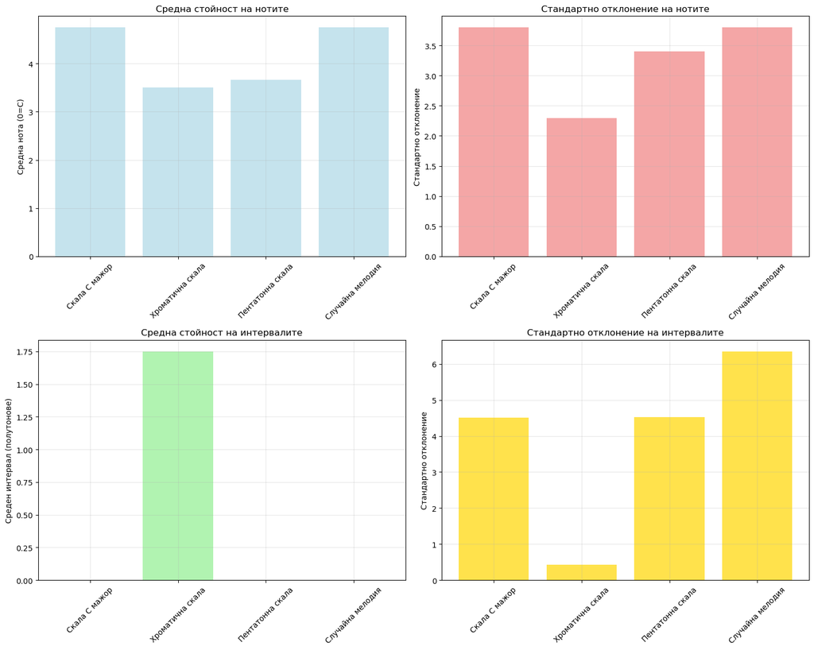

```
Статистически анализ на мелодиите:
============================================================

Скала C мажор:
  Ноти: ['C', 'D', 'E', 'F', 'G', 'A', 'B', 'C']
  Средна нота: 4.75 (стандартно отклонение: 3.80)
  Среден интервал: 0.00 полутона
  Стандартно отклонение на интервалите: 4.50
  Обхват: 11 полутона

Хроматична скала:
  Ноти: ['C', 'C#', 'D', 'D#', 'E', 'F', 'F#', 'G']
  Средна нота: 3.50 (стандартно отклонение: 2.29)
  Среден интервал: 1.75 полутона
  Стандартно отклонение на интервалите: 0.43
  Обхват: 7 полутона

Пентатонна скала:
  Ноти: ['C', 'D', 'E', 'G', 'A', 'C']
  Средна нота: 3.67 (стандартно отклонение: 3.40)
  Среден интервал: 0.00 полутона
  Стандартно отклонение на интервалите: 4.52
  Обхват: 9 полутона

Случайна мелодия:
  Ноти: ['C', 'F', 'B', 'D', 'G', 'E', 'A', 'C']
  Средна нота: 4.75 (стандартно отклонение: 3.80)
  Среден интервал: 0.00 полутона
  Стандартно отклонение на интервалите: 6.35
  Обхват: 11 полутона
```

```python
# Функция за анализ на интервали в мелодия
def analyze_melody_intervals(melody_notes):
    """Анализира интервалите в мелодия"""
    # Преобразуване на ноти в числа (C=0, D=2, E=4, ...)
    note_to_number = {
        'C': 0, 'D': 2, 'E': 4, 'F': 5, 'G': 7, 'A': 9, 'B': 11
    }

    numbers = [note_to_number[note] for note in melody_notes if note in note_to_number]

    # Изчисляване на интервалите
    intervals = []
    for i in range(1, len(numbers)):
        interval = numbers[i] - numbers[i-1]
        intervals.append(interval)

    return intervals

# Анализ на различни типове мелодии
melodies = {
    'Скала C мажор': ['C', 'D', 'E', 'F', 'G', 'A', 'B', 'C'],
    'Хроматична скала': ['C', 'C#', 'D', 'D#', 'E', 'F', 'F#', 'G'],
    'Пентатонна скала': ['C', 'D', 'E', 'G', 'A', 'C'],
    'Случайна мелодия': ['C', 'F', 'B', 'D', 'G', 'E', 'A', 'C']
}

# Преобразуване в числови стойности за статистически анализ
note_values = {'C': 0, 'C#': 1, 'D': 2, 'D#': 3, 'E': 4, 'F': 5,
               'F#': 6, 'G': 7, 'G#': 8, 'A': 9, 'A#': 10, 'B': 11}

melody_stats = {}
for melody_name, notes in melodies.items():
    # Преобразуване в числа
    numbers = [note_values.get(note, 0) for note in notes]

    # Основни статистики
    mean_note = np.mean(numbers)
    std_note = np.std(numbers)

    # Интервали
    intervals = analyze_melody_intervals(notes)
    mean_interval = np.mean(intervals) if intervals else 0
    std_interval = np.std(intervals) if intervals else 0

    melody_stats[melody_name] = {
        'notes': numbers,
        'mean_note': mean_note,
        'std_note': std_note,
        'intervals': intervals,
        'mean_interval': mean_interval,
        'std_interval': std_interval
    }

# Визуализация на статистиките
fig, axes = plt.subplots(2, 2, figsize=(15, 12))

# Средни стойности на нотите
melody_names = list(melody_stats.keys())
mean_notes = [melody_stats[name]['mean_note'] for name in melody_names]
std_notes = [melody_stats[name]['std_note'] for name in melody_names]

axes[0,0].bar(melody_names, mean_notes, color='lightblue', alpha=0.7)
axes[0,0].set_title('Средна стойност на нотите')
axes[0,0].set_ylabel('Средна нота (0=C)')
axes[0,0].tick_params(axis='x', rotation=45)
axes[0,0].grid(True, alpha=0.3)

# Стандартно отклонение на нотите
axes[0,1].bar(melody_names, std_notes, color='lightcoral', alpha=0.7)
axes[0,1].set_title('Стандартно отклонение на нотите')
axes[0,1].set_ylabel('Стандартно отклонение')
axes[0,1].tick_params(axis='x', rotation=45)
axes[0,1].grid(True, alpha=0.3)

# Средни интервали
mean_intervals = [melody_stats[name]['mean_interval'] for name in melody_names]
axes[1,0].bar(melody_names, mean_intervals, color='lightgreen', alpha=0.7)
axes[1,0].set_title('Средна стойност на интервалите')
axes[1,0].set_ylabel('Среден интервал (полутонове)')
axes[1,0].tick_params(axis='x', rotation=45)
axes[1,0].grid(True, alpha=0.3)

# Стандартно отклонение на интервалите
std_intervals = [melody_stats[name]['std_interval'] for name in melody_names]
axes[1,1].bar(melody_names, std_intervals, color='gold', alpha=0.7)
axes[1,1].set_title('Стандартно отклонение на интервалите')
axes[1,1].set_ylabel('Стандартно отклонение')
axes[1,1].tick_params(axis='x', rotation=45)
axes[1,1].grid(True, alpha=0.3)

plt.tight_layout()
plt.show()

# Детайлен статистически отчет
print("Статистически анализ на мелодиите:")
print("=" * 60)
for melody_name, stats in melody_stats.items():
    print(f"\n{melody_name}:")
    print(f"  Ноти: {melodies[melody_name]}")
    print(f"  Средна нота: {stats['mean_note']:.2f} (стандартно отклонение: {stats['std_note']:.2f})")
    print(f"  Среден интервал: {stats['mean_interval']:.2f} полутона")
    print(f"  Стандартно отклонение на интервалите: {stats['std_interval']:.2f}")
    print(f"  Обхват: {max(stats['notes']) - min(stats['notes'])} полутона")
```

### 6.3 Тестване на хипотези в музиката

#### Математически основи на статистическите тестове

**1. ANOVA тест (за сравняване на повече от две групи):**

**Нулева хипотеза:** $H_0: \mu_1 = \mu_2 = \cdots = \mu_k$

**F-статистика:** $$F = \frac{MSB}{MSW} = \frac{\sum_{i=1}^{k} n_i(\bar{x}_i - \bar{x})^2/(k-1)}{\sum_{i=1}^{k}\sum_{j=1}^{n_i}(x_{ij} - \bar{x}_i)^2/(N-k)}$$

където:

- $MSB$ = среден квадрат между групите
- $MSW$ = среден квадрат в групите
- $N = \sum_{i=1}^{k} n_i$ (общ брой наблюдения)

**2. t-тест за независими извадки:**

**t-статистика:** $$t = \frac{\bar{x}_1 - \bar{x}_2}{s_p \sqrt{\frac{1}{n_1} + \frac{1}{n_2}}}$$

**Pooled стандартно отклонение:** $$s_p = \sqrt{\frac{(n_1-1)s_1^2 + (n_2-1)s_2^2}{n_1 + n_2 - 2}}$$

**3. Pearson корелационен коефициент:** $$r = \frac{\sum_{i=1}^{n}(x_i - \bar{x})(y_i - \bar{y})}{\sqrt{\sum_{i=1}^{n}(x_i - \bar{x})^2}\sqrt{\sum_{i=1}^{n}(y_i - \bar{y})^2}}$$

**4. Shapiro-Wilk тест за нормалност:** $$W = \frac{(\sum_{i=1}^{n} a_i x_{(i)})^2}{\sum_{i=1}^{n} (x_i - \bar{x})^2}$$

където $x_{(i)}$ са подредените стойности и $a_i$ са коефициенти.

**5. Confidence Interval за средната стойност:** $$CI = \bar{x} \pm t_{\alpha/2, n-1} \cdot \frac{s}{\sqrt{n}}$$

Прилагаме статистически тестове за сравняване на различни музикални характеристики.

```
ТЕСТ 1: Разлики в темпото между жанровете
--------------------------------------------------
F-статистика: 51.2686
p-стойност: 0.000000
Резултат: Отхвърляме нулевата хипотеза (p < 0.05)
Заключение: Има статистически значима разлика в темпото между жанровете

Сравняване по двойки (t-тест):
Класическа vs Рок: t=-7.552, p=0.0000
Класическа vs Джаз: t=4.288, p=0.0000
Класическа vs Електронна: t=-5.193, p=0.0000
Рок vs Джаз: t=9.574, p=0.0000
Рок vs Електронна: t=4.016, p=0.0001
Джаз vs Електронна: t=-7.873, p=0.0000


ТЕСТ 2: Корелация между темпо и височина на нотите
-------------------------------------------------------
Pearson корелация: -0.1524
p-стойност: 0.002241
Силата на корелацията: слаба отрицателна
Заключение: Има статистически значима корелация (p < 0.05)


ТЕСТ 3: Нормално разпределение на височината на нотите
----------------------------------------------------------

Класическа:
  Shapiro-Wilk статистика: 0.9886
  p-стойност: 0.549953
  Заключение: Данните следват нормално разпределение (p > 0.05)

Рок:
  Shapiro-Wilk статистика: 0.9920
  p-стойност: 0.823066
  Заключение: Данните следват нормално разпределение (p > 0.05)

Джаз:
  Shapiro-Wilk статистика: 0.9931
  p-стойност: 0.896009
  Заключение: Данните следват нормално разпределение (p > 0.05)

Електронна:
  Shapiro-Wilk статистика: 0.9836
  p-стойност: 0.251568
  Заключение: Данните следват нормално разпределение (p > 0.05)
```

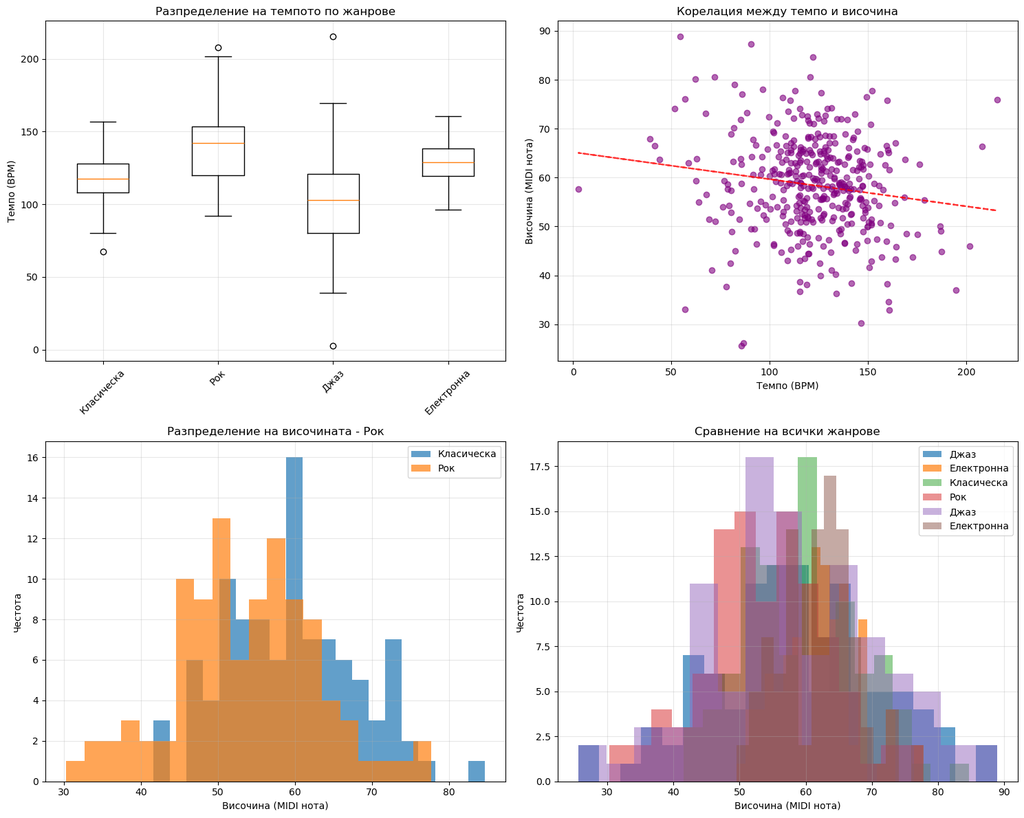

```
95% Confidence Intervals за средните стойности:
-------------------------------------------------------

Класическа:
  Темпо: 117.9 BPM, 95% CI: [114.3, 121.5]
  Височина: 59.6, 95% CI: [57.9, 61.2]

Рок:
  Темпо: 140.6 BPM, 95% CI: [135.8, 145.3]
  Височина: 53.8, 95% CI: [52.0, 55.7]

Джаз:
  Темпо: 101.9 BPM, 95% CI: [95.5, 108.4]
  Височина: 58.3, 95% CI: [55.7, 60.8]

Електронна:
  Темпо: 129.6 BPM, 95% CI: [127.0, 132.2]
  Височина: 62.0, 95% CI: [60.8, 63.1]
```

```python
from scipy import stats

# Генериране на данни за различни музикални жанрове
np.random.seed(42)  # за възпроизводимост

# Симулирани данни за темпо в различни жанрове
genres_tempo = {
    'Класическа': np.random.normal(120, 20, 100),  # средно 120 BPM
    'Рок': np.random.normal(140, 25, 100),         # средно 140 BPM
    'Джаз': np.random.normal(100, 30, 100),        # средно 100 BPM
    'Електронна': np.random.normal(128, 15, 100)   # средно 128 BPM
}

# Симулирани данни за средна височина на нотите
genres_pitch = {
    'Класическа': np.random.normal(60, 8, 100),    # около C4 (MIDI 60)
    'Рок': np.random.normal(55, 10, 100),          # малко по-ниска
    'Джаз': np.random.normal(58, 12, 100),         # средна
    'Електронна': np.random.normal(62, 6, 100)     # малко по-висока
}

# Хипотеза 1: Има ли значима разлика в темпото между жанровете?
def test_tempo_differences():
    print("ТЕСТ 1: Разлики в темпото между жанровете")
    print("-" * 50)

    # ANOVA тест за сравняване на повече от две групи
    tempo_groups = [genres_tempo[genre] for genre in genres_tempo.keys()]
    f_stat, p_value = stats.f_oneway(*tempo_groups)

    print(f"F-статистика: {f_stat:.4f}")
    print(f"p-стойност: {p_value:.6f}")

    alpha = 0.05
    if p_value < alpha:
        print(f"Резултат: Отхвърляме нулевата хипотеза (p < {alpha})")
        print("Заключение: Има статистически значима разлика в темпото между жанровете")
    else:
        print(f"Резултат: Не можем да отхвърлим нулевата хипотеза (p >= {alpha})")
        print("Заключение: Няма достатъчно доказателства за разлика в темпото")

    # Post-hoc анализ - сравняване по двойки
    print("\nСравняване по двойки (t-тест):")
    genre_names = list(genres_tempo.keys())
    for i in range(len(genre_names)):
        for j in range(i+1, len(genre_names)):
            genre1, genre2 = genre_names[i], genre_names[j]
            t_stat, p_val = stats.ttest_ind(genres_tempo[genre1], genres_tempo[genre2])
            print(f"{genre1} vs {genre2}: t={t_stat:.3f}, p={p_val:.4f}")

# Хипотеза 2: Корелира ли темпото с височината на нотите?
def test_tempo_pitch_correlation():
    print(f"\n\nТЕСТ 2: Корелация между темпо и височина на нотите")
    print("-" * 55)

    # Комбиниране на данните от всички жанрове
    all_tempos = np.concatenate([genres_tempo[genre] for genre in genres_tempo.keys()])
    all_pitches = np.concatenate([genres_pitch[genre] for genre in genres_pitch.keys()])

    # Pearson корелация
    correlation, p_value = stats.pearsonr(all_tempos, all_pitches)

    print(f"Pearson корелация: {correlation:.4f}")
    print(f"p-стойност: {p_value:.6f}")

    # Интерпретация на силата на корелацията
    if abs(correlation) < 0.1:
        strength = "много слаба"
    elif abs(correlation) < 0.3:
        strength = "слаба"
    elif abs(correlation) < 0.5:
        strength = "умерена"
    elif abs(correlation) < 0.7:
        strength = "силна"
    else:
        strength = "много силна"

    direction = "положителна" if correlation > 0 else "отрицателна"

    print(f"Силата на корелацията: {strength} {direction}")

    alpha = 0.05
    if p_value < alpha:
        print(f"Заключение: Има статистически значима корелация (p < {alpha})")
    else:
        print(f"Заключение: Няма статистически значима корелация (p >= {alpha})")

# Хипотеза 3: Следва ли височината на нотите нормално разпределение?
def test_pitch_normality():
    print(f"\n\nТЕСТ 3: Нормално разпределение на височината на нотите")
    print("-" * 58)

    for genre, pitches in genres_pitch.items():
        # Shapiro-Wilk тест за нормалност
        stat, p_value = stats.shapiro(pitches)

        print(f"\n{genre}:")
        print(f"  Shapiro-Wilk статистика: {stat:.4f}")
        print(f"  p-стойност: {p_value:.6f}")

        alpha = 0.05
        if p_value > alpha:
            print(f"  Заключение: Данните следват нормално разпределение (p > {alpha})")
        else:
            print(f"  Заключение: Данните НЕ следват нормално разпределение (p <= {alpha})")

# Изпълнение на тестовете
test_tempo_differences()
test_tempo_pitch_correlation()
test_pitch_normality()

# Визуализация на резултатите
fig, axes = plt.subplots(2, 2, figsize=(15, 12))

# Boxplot за темпо по жанрове
tempo_data = [genres_tempo[genre] for genre in genres_tempo.keys()]
tempo_labels = list(genres_tempo.keys())
axes[0,0].boxplot(tempo_data, tick_labels=tempo_labels)
axes[0,0].set_title('Разпределение на темпото по жанрове')
axes[0,0].set_ylabel('Темпо (BPM)')
axes[0,0].tick_params(axis='x', rotation=45)
axes[0,0].grid(True, alpha=0.3)

# Scatter plot за корелацията темпо-височина
all_tempos = np.concatenate([genres_tempo[genre] for genre in genres_tempo.keys()])
all_pitches = np.concatenate([genres_pitch[genre] for genre in genres_pitch.keys()])
axes[0,1].scatter(all_tempos, all_pitches, alpha=0.6, color='purple')
axes[0,1].set_title('Корелация между темпо и височина')
axes[0,1].set_xlabel('Темпо (BPM)')
axes[0,1].set_ylabel('Височина (MIDI нота)')
axes[0,1].grid(True, alpha=0.3)

# Добавяне на линия на тренда
z = np.polyfit(all_tempos, all_pitches, 1)
p = np.poly1d(z)
axes[0,1].plot(all_tempos, p(all_tempos), "r--", alpha=0.8)

# Histogram за височината в различни жанрове
for i, (genre, pitches) in enumerate(genres_pitch.items()):
    axes[1, i//2].hist(pitches, bins=20, alpha=0.7, label=genre)
    axes[1, i//2].set_title(f'Разпределение на височината - {genre}')
    axes[1, i//2].set_xlabel('Височина (MIDI нота)')
    axes[1, i//2].set_ylabel('Честота')
    axes[1, i//2].grid(True, alpha=0.3)
    axes[1, i//2].legend()

# За четвъртия subplot - сравнение на всички жанрове
if len(genres_pitch) > 2:
    for genre, pitches in genres_pitch.items():
        axes[1,1].hist(pitches, bins=15, alpha=0.5, label=genre)
    axes[1,1].set_title('Сравнение на всички жанрове')
    axes[1,1].set_xlabel('Височина (MIDI нота)')
    axes[1,1].set_ylabel('Честота')
    axes[1,1].legend()
    axes[1,1].grid(True, alpha=0.3)

plt.tight_layout()
plt.show()

# Confidence intervals за средните стойности
print(f"\n\n95% Confidence Intervals за средните стойности:")
print("-" * 55)

for genre in genres_tempo.keys():
    # За темпо
    tempo_mean = np.mean(genres_tempo[genre])
    tempo_sem = stats.sem(genres_tempo[genre])
    tempo_ci = stats.t.interval(0.95, len(genres_tempo[genre])-1,
                               loc=tempo_mean, scale=tempo_sem)

    # За височина
    pitch_mean = np.mean(genres_pitch[genre])
    pitch_sem = stats.sem(genres_pitch[genre])
    pitch_ci = stats.t.interval(0.95, len(genres_pitch[genre])-1,
                               loc=pitch_mean, scale=pitch_sem)

    print(f"\n{genre}:")
    print(f"  Темпо: {tempo_mean:.1f} BPM, 95% CI: [{tempo_ci[0]:.1f}, {tempo_ci[1]:.1f}]")
    print(f"  Височина: {pitch_mean:.1f}, 95% CI: [{pitch_ci[0]:.1f}, {pitch_ci[1]:.1f}]")
```

## 7. Заключение и приложения

### 7.1 Обобщение на резултатите

**Ключови изводи:**

1. **Физика на звука**: Синусоидалните функции перфектно описват звуковите вълни, а математическите отношения между честотите определят музикалните интервали.
2. **Комплексни числа**: Формулата на Ойлер предоставя елегантен начин за анализ на фазовите отношения и интерференцията между тонове.
3. **Линейна алгебра**: Векторното представяне на акорди позволява количествен анализ на хармоничните отношения и трансформации.
4. **Математически анализ**: Производните и интегралите ни дават възможност да анализираме динамиката и енергията на музикалните сигнали.
5. **Вероятност и статистика**: Марковските вериги могат да моделират музикалната композиция, а статистическите тестове - да анализират различията между музикалните жанрове.

### 7.2 Математически модели в музиката

#### Синусоидални функции

**Формула:** $f(t) = A \cdot \sin(2\pi\nu t + \varphi)$

**Приложение:** Описание на звуковите вълни

**Параметри:**

- $A$ - амплитуда
- $\nu$ - честота
- $\varphi$ - фаза

#### Комплексни експоненциали

**Формула:** $z(t) = A \cdot e^{i(2\pi\nu t + \varphi)}$

**Приложение:** Анализ на фазови отношения

**Параметри:** Базирани на формулата на Ойлер

**Връзка с Ойлер:** $e^{i\theta} = \cos(\theta) + i\sin(\theta)$

#### Векторни пространства

**Формула:** $V \in \mathbb{R}^{12}$ (хроматично пространство)

**Приложение:** Представяне на акорди и хармонии

**Параметри:** 12-мерен хроматичен вектор

**Пример:** $C_{major} = [1, 0, 0, 0, 1, 0, 0, 1, 0, 0, 0, 0]$

#### Fourier трансформация

**Формула:** $X(\omega) = \int_{-\infty}^{\infty} x(t)e^{-i\omega t} dt$

**Приложение:** Спектрален анализ на музикални сигнали

**Параметри:**

- Честотна област vs времева област
- Декомпозиция на сложни звуци

**Дискретна версия:** $X[k] = \sum_{n=0}^{N-1} x[n]e^{-i2\pi kn/N}$

#### Марковски вериги

**Формула:** $P(X_{n+1} = j | X_n = i) = p_{ij}$

**Приложение:** Моделиране на музикални последователности

**Параметри:** Матрица на преходните вероятности

**Матричен запис:** $$P = \begin{pmatrix} p_{11} & p_{12} & \cdots & p_{1n} \\ p_{21} & p_{22} & \cdots & p_{2n} \\ \vdots & \vdots & \ddots & \vdots \\ p_{n1} & p_{n2} & \cdots & p_{nn} \end{pmatrix}$$

### 7.3 Практически приложения

Математическите принципи изследвани в този проект имат широки практически приложения:

**В музикалната технология:**

- Цифрова обработка на звук
- Музикални синтезатори
- Алгоритми за компресия на аудио
- Автоматично разпознаване на музика

**В музикалното образование:**

- Визуализация на хармоничните отношения
- Анализ на музикални форми
- Компютърно подпомогнато композиране

**В изследванията:**

- Анализ на музикални предпочитания
- Моделиране на когнитивни процеси при възприемане на музика
- Междукултурни музикални изследвания

### 7.4 Ограничения и бъдещи насоки

**Ограничения на този проект:**

- Фокус върху западната тонална музика
- Опростени модели за сложни музикални явления
- Ограничен анализ на ритъма и метъра

**Възможности за разширение:**

- Включване на микротонални системи
- Анализ на етническа и световна музика
- Машинно обучение за музикален анализ
- Психоакустични модели

### 7.5 Финална демонстрация

#### Математически синтез на всички концепции

**Интегриран математически модел:**

**Комплексно представяне на акорда:** $$z_{chord}(t) = \sum_{i=1}^{n} e^{j2\pi f_i t}$$

**Векторно представяне:** $$\mathbf{v}_{chord} = (v_0, v_1, \ldots, v_{11}) \in \{0,1\}^{12}$$

**Fourier анализ:** $$Z[k] = \sum_{n=0}^{N-1} z_{chord}[n] \cdot e^{-j\frac{2\pi kn}{N}}$$

**Енергиен анализ:** $$E_{total} = \int_0^T |z_{chord}(t)|^2 dt = \sum_{n=0}^{N-1} |z_{chord}[n]|^2 \cdot \Delta t$$

**Статистически параметри:**

- **Средна честота:** $\bar{f} = \frac{\sum_{k} f_k |Z[k]|^2}{\sum_{k} |Z[k]|^2}$
- **RMS амплитуда:** $A_{RMS} = \sqrt{\frac{E_{total}}{T}}$

**Комбиниран анализ:** $$\text{Complexity}_{total} = \alpha \|\mathbf{v}\|_1 + \beta H_{entropy} + \gamma E_{total} + \delta \sigma_f$$

където:

- $\alpha, \beta, \gamma, \delta$ са тегловни коефициенти
- $H_{entropy}$ е ентропията на честотното разпределение
- $\sigma_f$ е стандартното отклонение на честотите

**7Математическа оценка на хармоничност:** $$\text{Harmony}_{score} = \frac{\text{sim}(\mathbf{v}_{chord}, \mathbf{v}_{reference})}{\sqrt{E_{dissonance}}}$$

Финална демонстрация - синтез на всички математически концепции за създаване на интерактивен музикално-математически анализ.

```
ФИНАЛНА ДЕМОНСТРАЦИЯ: МУЗИКАЛНО-МАТЕМАТИЧЕСКИ СИНТЕЗ
=================================================================
Резултати от интегрирания анализ:
  Акорд: C мажор (C-E-G)
  Честоти: [261.63, 329.63, 392.0] Hz
  Хроматичен вектор: [1. 0. 0. 0. 1. 0. 0. 1. 0. 0. 0. 0.]
  Обща енергия: 3.0054
  Средна честота: 2223.89 Hz
```

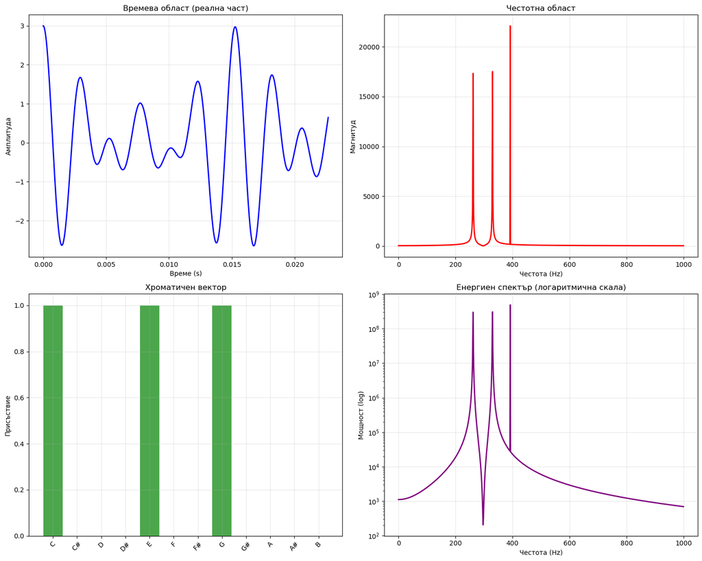

```python
# Финална демонстрация - синтез на всички концепции

def create_chromatic_vector(notes):
    """
    Създава хроматичен вектор за дадени ноти
    notes: списък с номера на нотите (0-11, където 0=C, 1=C#, и т.н.)
    """
    vector = np.zeros(12)
    for note in notes:
        vector[note % 12] = 1
    return vector

def final_demonstration():
    """
    Финална демонстрация, която комбинира всички математически концепции
    за създаване на интерактивен музикално-математически анализ
    """
    print("ФИНАЛНА ДЕМОНСТРАЦИЯ: МУЗИКАЛНО-МАТЕМАТИЧЕСКИ СИНТЕЗ")
    print("=" * 65)

    # 1. Генериране на акорд използвайки комплексни числа
    frequencies = [261.63, 329.63, 392.00]  # C мажор
    duration = 1.0
    sample_rate = 44100

    t = np.linspace(0, duration, int(sample_rate * duration), False)
    chord_signal = np.zeros(len(t), dtype=complex)

    for freq in frequencies:
        wave = np.exp(1j * 2 * np.pi * freq * t)
        chord_signal += wave

    # 2. Векторен анализ на акорда
    chord_vector = create_chromatic_vector([0, 4, 7])  # C-E-G

    # 3. Fourier анализ
    fft_result = np.fft.fft(np.real(chord_signal))
    freqs = np.fft.fftfreq(len(chord_signal), 1/sample_rate)

    # 4. Енергиен анализ чрез интегрирване
    energy = np.trapz(np.abs(chord_signal)**2, dx=1/sample_rate)

    # 5. Статистически анализ
    chord_freqs = np.abs(fft_result)
    mean_freq = np.average(freqs[freqs > 0], weights=chord_freqs[freqs > 0])

    print("Резултати от интегрирания анализ:")
    print(f"  Акорд: C мажор (C-E-G)")
    print(f"  Честоти: {frequencies} Hz")
    print(f"  Хроматичен вектор: {chord_vector}")
    print(f"  Обща енергия: {energy:.4f}")
    print(f"  Средна честота: {mean_freq:.2f} Hz")

    # Визуализация на финалните резултати
    fig, axes = plt.subplots(2, 2, figsize=(15, 12))

    # Времева област
    axes[0,0].plot(t[:1000], np.real(chord_signal[:1000]), 'b-', linewidth=2)
    axes[0,0].set_title('Времева област (реална част)')
    axes[0,0].set_xlabel('Време (s)')
    axes[0,0].set_ylabel('Амплитуда')
    axes[0,0].grid(True, alpha=0.3)

    # Честотна област
    positive_freq_mask = (freqs >= 0) & (freqs <= 1000)
    axes[0,1].plot(freqs[positive_freq_mask], np.abs(fft_result[positive_freq_mask]), 'r-', linewidth=2)
    axes[0,1].set_title('Честотна област')
    axes[0,1].set_xlabel('Честота (Hz)')
    axes[0,1].set_ylabel('Магнитуд')
    axes[0,1].grid(True, alpha=0.3)

    # Хроматичен вектор
    note_names = ['C', 'C#', 'D', 'D#', 'E', 'F', 'F#', 'G', 'G#', 'A', 'A#', 'B']
    axes[1,0].bar(range(12), chord_vector, color='green', alpha=0.7)
    axes[1,0].set_title('Хроматичен вектор')
    axes[1,0].set_xticks(range(12))
    axes[1,0].set_xticklabels(note_names, rotation=45)
    axes[1,0].set_ylabel('Присъствие')
    axes[1,0].grid(True, alpha=0.3)

    # Енергийно разпределение
    power_spectrum = np.abs(fft_result)**2
    axes[1,1].semilogy(freqs[positive_freq_mask], power_spectrum[positive_freq_mask], 'purple', linewidth=2)
    axes[1,1].set_title('Енергиен спектър (логаритмична скала)')
    axes[1,1].set_xlabel('Честота (Hz)')
    axes[1,1].set_ylabel('Мощност (log)')
    axes[1,1].grid(True, alpha=0.3)

    plt.tight_layout()
    plt.show()

    return {
        'chord_vector': chord_vector,
        'energy': energy,
        'mean_frequency': mean_freq,
        'signal': chord_signal
    }

# Изпълнение на финалната демонстрация
final_results = final_demonstration()
```

### 7.6 Заключителни мисли

Математиката и музиката споделят фундаментални принципи на хармония, структура и красота. Този проект демонстрира как математическите концепции от курса "Math Concepts for Developers" могат да осветлят музикалните явления и да предоставят нови инструменти за анализ и създаване на музика.

**Основни постижения:**

**Научен принос:** Проектът показва силата на междудисциплинарния подход, където математиката служи като универсален език за описване на сложни явления в изкуството. Резултатите могат да бъдат приложени в областите на музикалната технология, образованието и изследванията.

**Практическа стойност:** Разработените инструменти и методи могат да бъдат използвани от:

- Музиканти за по-добро разбиране на хармоничните отношения
- Разработчици на музикален софтуер
- Изследователи в областта на музикознанието и когнитивните науки
- Преподаватели по математика за демонстрация на практическите приложения

**Заключение:** Математиката не само обяснява музиката - тя я прави по-богата, по-разбираема и по-достъпна за анализ и творчество. Този проект е доказателство за универсалността на математическите принципи и тяхната способност да свързват различни области на човешкото знание и творчество.

## Благодарности

Този проект е разработен като част от курса "Math Concepts for Developers" в SoftUni. Благодаря на Йордан Даракчиев и Softuni, които допринесоха за пореден път за попълването на познанията ми в областта на науката.

## Източници и литература

1. Xenakis, I. (1971). *Formalized Music: Thought and Mathematics in Composition*
2. Roads, C. (1996). *The Computer Music Tutorial*
3. Loy, G. (2006). *Musimathics: The Mathematical Foundations of Music*
4. Temperley, D. (2001). *The Cognition of Basic Musical Structures*
5. Курсови материали от "Math Concepts for Developers", SoftUni

**Автор:** [Антон Ненов]  
**Дата:** [5.06.2025]  
**Курс:** Math Concepts for Developers 2025  
**Институция:** SoftUni